# Practical Machine Learning - Course Project

npanei

## Introduction

This project analyzes a data set concerning several different types of exercise, and the readout from several motion-sensing devices on the exercising person’s body. The goal of the project is to use the readouts from those sensors to predict what type of exercise is being performed. This project uses machine learning techniques to create a predictive model.

## Data Cleaning and Pre-Processing

```r
# load files and relevant libraries
download.file("https://d396qusza40orc.cloudfront.net/predmachlearn/pml-training.csv","pml-training.csv")
training <- read.csv("pml-training.csv",na.strings=c("NA",""))
download.file("https://d396qusza40orc.cloudfront.net/predmachlearn/pml-testing.csv","pml-testing.csv")
testing <- read.csv("pml-testing.csv")

library(caret)
```

The “training” set used here consists of 19,622 observations of 160 variables. Of these, 100 variables are almost completely empty; they have over 19,000 “NA” values. After eliminating these, and additionally a few irrelevant variables such as timestamps and dates, 52 independent variables remain.

```r
# eliminate variates with a large number of missing values in the training set
k <- c()
for (i in 1:160) {
    k[i] <- sum(is.na(training[,i])) < 19000
}
training <- training[,k]
# eliminate add'l  useless variates such as timestamps
training <- training[,-c(1:7)]
```

As an additional measure, we will not train on the entire data set. Pre-processing and performing training on the entire set of 19,622 observations would take an unreasonably long time. In order to expedite the analysis, and additionally as a cross-validation technique, only 20% of the “training” data set will actually be used for training. The other 80% will be used for validation.

```r
# partition the data
set.seed(120)
inTrain <- createDataPartition(training$classe, p = 0.2)[[1]]
realTrain <- training[ inTrain,]
validTrain <- training[-inTrain,]
```

In order to simplify the problem, we will use principal component analysis (PCA) pre-processing on our data set. The threshold for the number of PCs used will be 80%. As shown below, 80% of the variance in the data set is captured by the first five PCAs. Thus, the number of independent variables to be analyzed will be reduced from 52 to 5.

```r
fitPCA <- prcomp(training[,-53])
summary(fitPCA)$importance[,1:5]
```

```
##                              PC1       PC2       PC3       PC4       PC5
## Standard deviation     599.33610 534.17983 471.24239 378.58825 355.91845
## Proportion of Variance   0.26347   0.20930   0.16288   0.10513   0.09292
## Cumulative Proportion    0.26347   0.47277   0.63565   0.74078   0.83370
```

```r
ctrl <- trainControl(preProcOptions = list(thresh = 0.8))
```

## Model Selection

Two different machine learning methods will be used to generate the models: random forest (“RF”) and boosting with trees (“GBM”). To select the final model, we will simply compare the accuracy of the models on the validation data set.

```r
# generate models
# the first model training function produces warnings but works fine
suppressWarnings(model1 <- train(classe ~ .,method="rf",data=realTrain,
                preProcess="pca",trControl=ctrl))
model2 <- train(classe ~ .,method="gbm",data=realTrain,
                preProcess="pca",trControl=ctrl,verbose=FALSE)

# compute accuracy on training and validation data sets
predict1 <- predict(model1,realTrain)
valid1 <- predict(model1,validTrain)
predict2 <- predict(model2,realTrain)
valid2 <- predict(model2,validTrain)

acclist <- c(confusionMatrix(predict1,realTrain$classe)$overall[1],
             confusionMatrix(valid1,validTrain$classe)$overall[1],
             confusionMatrix(predict2,realTrain$classe)$overall[1],
             confusionMatrix(valid2,validTrain$classe)$overall[1])
names(acclist) <- c("RF (Train)","RF (Val)", "GBM (Train)", "GBM (Val)")
acclist # accuracy comparison
```

```
##  RF (Train)    RF (Val) GBM (Train)   GBM (Val)
##   1.0000000   0.8899650   0.8444105   0.7363492
```

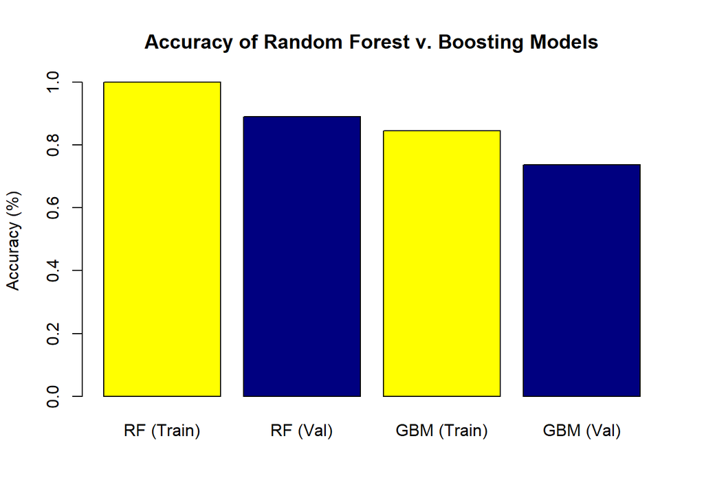

```r
# plot results
barplot(acclist,ylab="Accuracy (%)",col=c("yellow1","navy"),
        main="Accuracy of Random Forest v. Boosting Models")
```

The random forest model clearly outperformed the boosting model, with an accuracy of 89% versus 74% on the validation set. The 100% accuracy of the random forest model on the training set may suggest overfitting, but the cross-validated accuracy of 89% suggests that it’s not to a problematic degree. Therefore, for our final selection, we choose the random forest model. As a last note, we expect our out-of-sample error rate to be approximately the error rate of the model on the validation set: 11%.